# Student Alcohol Consumption

Sachie Tran

2/14/2022

## Introduction

The data “student alcohol consumption” is collected from secondary school students who take both/either math and/or Portuguese language courses in Portugal. This includes over 1000 samples from various aspects like social, family, personal lifestyle and study status. The main purpose of this case study is to find how alcohol consumption relates to students, and how to control it for their academic goals, hoping to help young people and their family members achieve students’ academic goals.

The original data is available from [Kaggle](https://www.kaggle.com/uciml/student-alcohol-consumption?select=student-mat.csv).

## Data Explore

- Summary of data

```r
#install.packages("tidyverse")
#library(tidyverse)
#install.packages("dplyr")
library(dplyr)
#install.packages("reshape2")
library(reshape2)
```

```r
students <- read.csv("all_students.csv")
head(students)
```

```
##   school sex age address famsize Pstatus Medu Fedu     Mjob     Fjob     reason
## 1     GP   F  15       R     GT3       T    1    1  at_home    other       home
## 2     GP   F  15       R     GT3       T    1    1    other    other     course
## 3     GP   F  15       R     GT3       T    1    1    other    other reputation
## 4     GP   F  15       R     GT3       T    2    2  at_home    other reputation
## 5     GP   F  15       R     GT3       T    2    4 services   health     course
## 6     GP   F  15       R     GT3       T    3    3 services services reputation
##   guardian traveltime studytime failures schoolsup famsup paid activities
## 1   mother          2         4        0       yes    yes  yes        yes
## 2   mother          3         1        1        no     no   no        yes
## 3   mother          1         2        0       yes    yes   no         no
## 4   mother          1         1        0       yes    yes   no        yes
## 5   mother          1         3        0       yes    yes   no        yes
## 6    other          2         3        0        no    yes  yes        yes
##   nursery higher internet romantic famrel freetime goout Dalc Walc health
## 1     yes    yes      yes       no      3        1     2    1    1      1
## 2     yes    yes      yes      yes      5        5     5    1    1      1
## 3      no    yes      yes      yes      3        3     4    2    4      5
## 4     yes    yes       no       no      4        3     1    1    1      2
## 5     yes    yes      yes       no      4        3     2    1    1      5
## 6     yes    yes      yes      yes      4        2     1    2    3      3
##   absences G1 G2 G3     course
## 1        4 13 13 13 Portuguese
## 2        2  8  9  9 Portuguese
## 3        2 13 11 11 Portuguese
## 4        8 14 13 12 Portuguese
## 5        2 10 11 10 Portuguese
## 6        2 13 13 13 Portuguese
```

First, I would go through simple aggregations to get to know the data.

- Gender ratio

```r
Sex_tbl <- table(students$sex)  #F=Female, M=Male
Sex_tbl <- prop.table(Sex_tbl)*100
Sex_tbl <- round(Sex_tbl,digits=2)
Sex_tbl
```

```
##
##     F     M
## 58.91 41.09
```

- Age and gender ratio

```r
AgeSex_tbl <- table(students$age, students$sex)
AgeSex_tbl <- prop.table(AgeSex_tbl)*100
AgeSex_tbl <- round(AgeSex_tbl,digits=2)
AgeSex_tbl
```

```
##
##          F     M
##   15  8.61  8.31
##   16 15.41 10.73
##   17 16.92  9.97
##   18 12.84  8.61
##   19  4.23  2.57
##   20  0.76  0.45
##   21  0.15  0.30
##   22  0.00  0.15
```

Insights : Over 91 percent of students are under age 19, and nearly 60 percent of students are female.

- Average grade by gender

```r
Ave_grade_sex <- students %>%
  group_by(sex)%>%
  summarise(mean_grade_g1=mean(G1),mean_grade_g2=mean(G2),mean_grade_g3=mean(G3))
Ave_grade_sex
```

```
## # A tibble: 2 x 4
##   sex   mean_grade_g1 mean_grade_g2 mean_grade_g3
##   <chr>         <dbl>         <dbl>         <dbl>
## 1 F              11.5          11.5          11.9
## 2 M              11.0          11.1          11.1
```

Insights : No gender gaps are found in academic grades.

Since the age composition in this data is unique, I need to be careful with my analysis that includes the ‘age’ attribute. I would explore for more findings.

### - Alcohol consumption by gender and age

```r
library(ggplot2)

# create table and plot that show alcohol consumption by age
# Dalc : workday alcohol consumption, Walc : weekend alcohol consumption (1:very low - 5:very high)

Alcohol_AgeSex <- students %>%
  group_by(age,sex)%>%
  summarise(mean_dalc=mean(Dalc),mean_walc=mean(Walc))
Alcohol_AgeSex
```

```
## # A tibble: 15 x 4
## # Groups:   age [8]
##      age sex   mean_dalc mean_walc
##    <int> <chr>     <dbl>     <dbl>
##  1    15 F          1.35      1.89
##  2    15 M          1.42      2.16
##  3    16 F          1.22      1.95
##  4    16 M          1.68      2.69
##  5    17 F          1.25      1.98
##  6    17 M          2.08      3.21
##  7    18 F          1.22      1.85
##  8    18 M          2.05      3.16
##  9    19 F          1.68      2
## 10    19 M          1.59      2.12
## 11    20 F          1.2       2.2
## 12    20 M          2.33      3.33
## 13    21 F          1         1
## 14    21 M          4         2.5
## 15    22 M          5         5
```

#### Workday

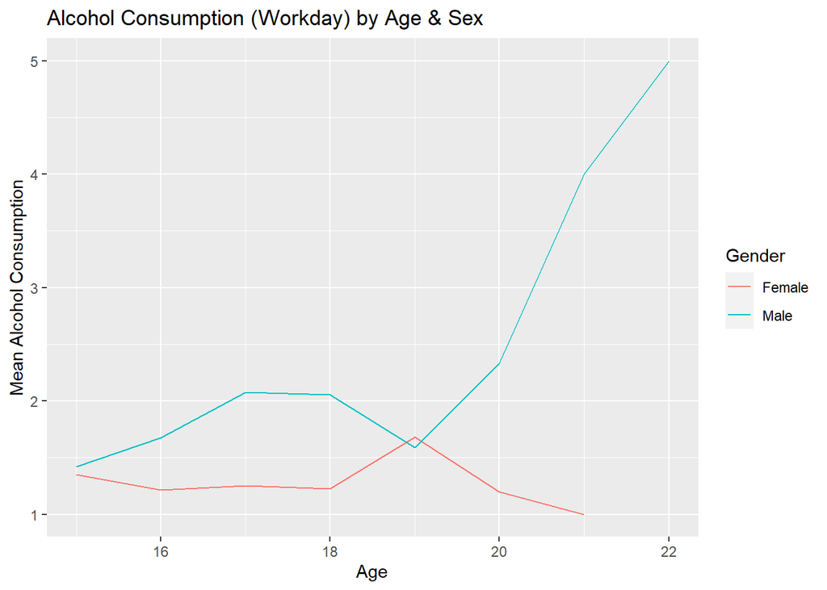

```r
ggplot(Alcohol_AgeSex, aes(x=age, y=mean_dalc, colour = sex)) +
  labs(title = "Alcohol Consumption (Workday) by Age & Sex",
       x ='Age', y ='Mean Alcohol Consumption')+
  scale_colour_discrete(name = "Gender", labels = c("Female", "Male"))+
  geom_line()
```

#### Weekend

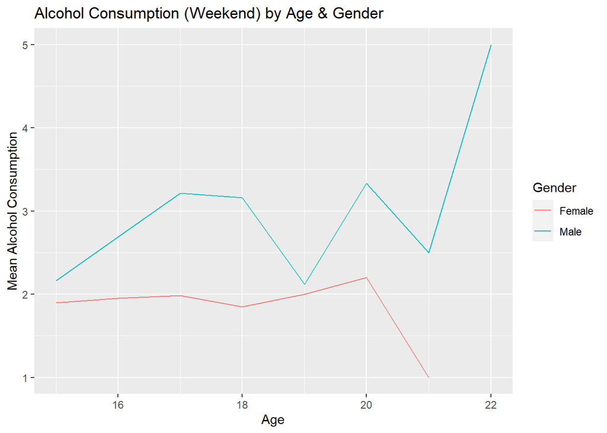

```r
ggplot(Alcohol_AgeSex, aes(x=age, y=mean_walc, colour = sex)) +
  labs(title = "Alcohol Consumption (Weekend) by Age & Gender",
       x ='Age', y ='Mean Alcohol Consumption')+
  scale_colour_discrete(name = "Gender", labels = c("Female", "Male"))+
  geom_line()
```

### - School grade by gender and age

```r
# create table and plot that show school grade by age & gender

grade_AgeSex <- students %>%
  group_by(age,sex)%>%
  summarise(mean_grade1=mean(G1),mean_grade2=mean(G2),mean_grade3=mean(G3))
grade_AgeSex
```

```
## # A tibble: 15 x 5
## # Groups:   age [8]
##      age sex   mean_grade1 mean_grade2 mean_grade3
##    <int> <chr>       <dbl>       <dbl>       <dbl>
##  1    15 F           11.5        11.2        11.4
##  2    15 M           11.4        11.7        11.9
##  3    16 F           11.9        11.9        12.3
##  4    16 M           11.3        10.9        11.1
##  5    17 F           11.8        12.2        12.7
##  6    17 M           10.8        10.8        11.0
##  7    18 F           11.2        11.1        11.4
##  8    18 M           11.1        11.3        11.2
##  9    19 F            9.93        9.32        9.25
## 10    19 M            9.41       10           9.76
## 11    20 F           11          12          12.4
## 12    20 M           11.3        12.7        12.3
## 13    21 F            9          12          12
## 14    21 M            9.5         9           8.5
## 15    22 M            7           8           5
```

#### 1st period

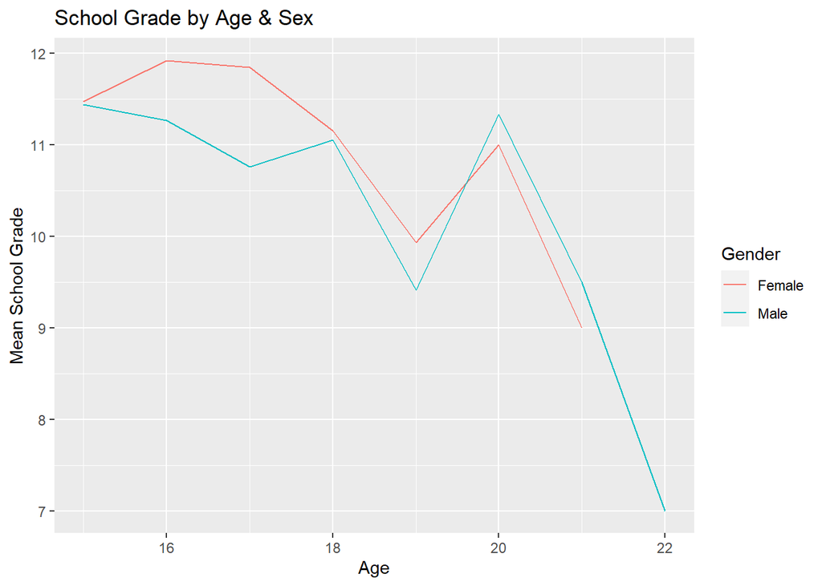

```r
ggplot(grade_AgeSex, aes(x=age, y=mean_grade1, colour = sex)) +
    labs(title = "School Grade by Age & Sex",
       x ='Age', y ='Mean School Grade') +
  scale_colour_discrete(name ='Gender', labels =  c('Female','Male'))+
  geom_line()
```

#### 2nd period

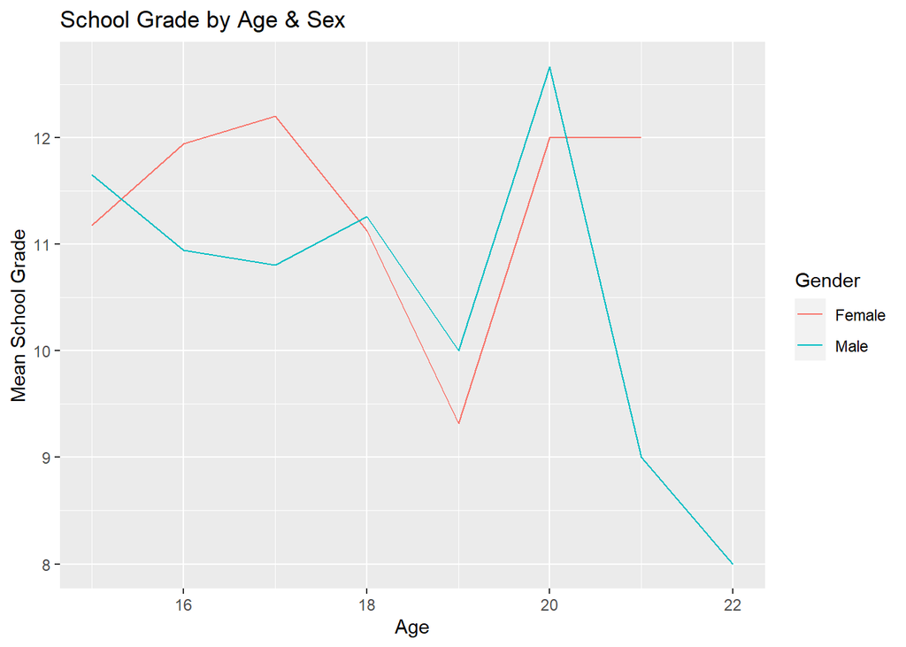

```r
ggplot(grade_AgeSex, aes(x=age, y=mean_grade2, colour = sex)) +
    labs(title = "School Grade by Age & Sex",
       x ='Age', y ='Mean School Grade') +
  scale_colour_discrete(name ='Gender', labels =  c('Female','Male'))+
  geom_line()
```

#### 3rd period

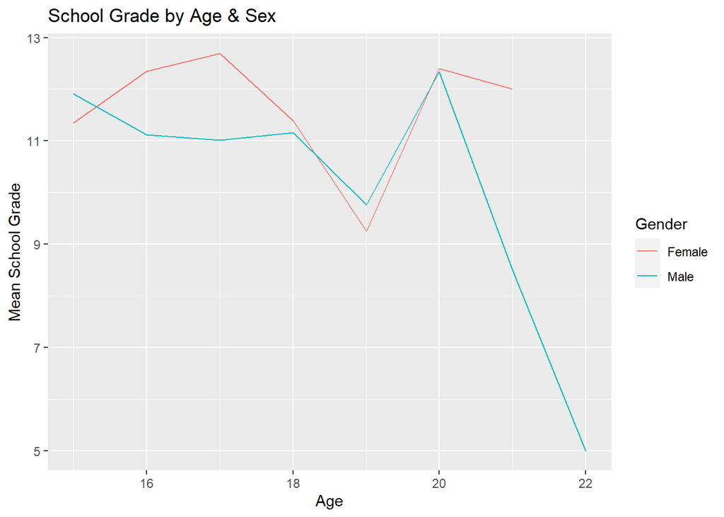

```r
ggplot(grade_AgeSex, aes(x=age, y=mean_grade3, colour = sex)) +
    labs(title = "School Grade by Age & Sex",
       x ='Age', y ='Mean School Grade') +
  scale_colour_discrete(name ='Gender', labels =  c('Female','Male'))+
  geom_line()
```

## Problem

The previous charts “Alcohol Consumption by Age & Sex” show that male’s alcohol intake increases as age increases, but female doesn’t. The charts “School Grade by Age & Sex” show opposite results from the previous charts that male’s mean school grades decline with increasing age, which seems to be a correlate movement with alcohol consumption. Since average grades have no gender gaps, these results suggest that age or gender is not likely to be the factor of students’ grade, but the amount of drinking would be.

To understand more about students’ consumption of alcohol, these questions arise;

- Does alcohol consumption affect students’ health, how?
- Does alcohol consumption relate to students’ school outcome, how?

By finding answers for these questions, I am hoping to find a way to help current/future students to control their alcohol amount and achieve their academic goals.

For the first question, **does alcohol consumption affect students’ health, how?** I would compare students’ alcohol amount to their health self-assessment.

### - Health Status vs Alcohol Consumption

```r
#health : health status  (1:very bad - 5:very good)

health_alc <- students %>%
  group_by(health)%>%
  summarise(mean_dalc=mean(Dalc),mean_walc=mean(Walc))
health_alc
```

```
## # A tibble: 5 x 3
##   health mean_dalc mean_walc
##    <int>     <dbl>     <dbl>
## 1      1      1.46      1.99
## 2      2      1.38      2.20
## 3      3      1.45      2.19
## 4      4      1.55      2.29
## 5      5      1.57      2.46
```

#### Workday

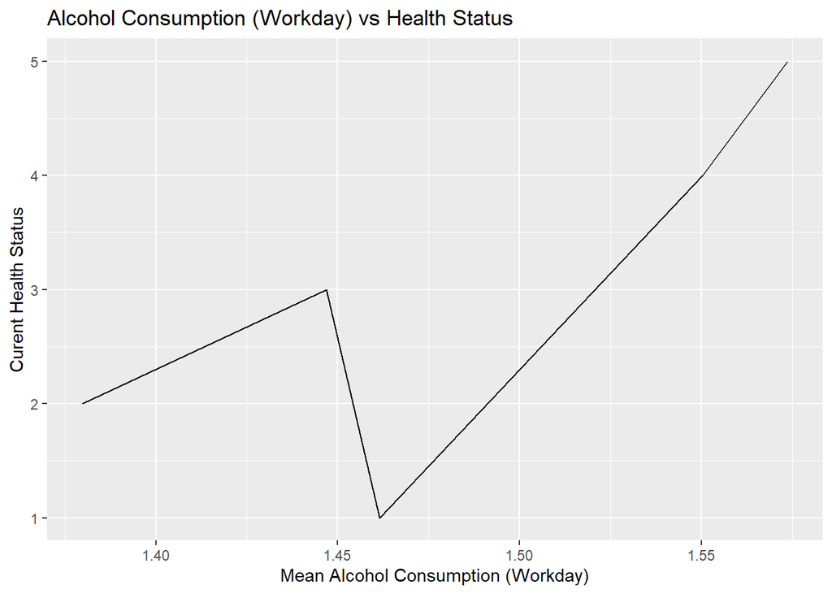

```r
ggplot(health_alc, aes(x=mean_dalc, y=health)) +
  labs(title = "Alcohol Consumption (Workday) vs Health Status",
        x ='Mean Alcohol Consumption (Workday)', y ='Curent Health Status')+
  geom_line()
```

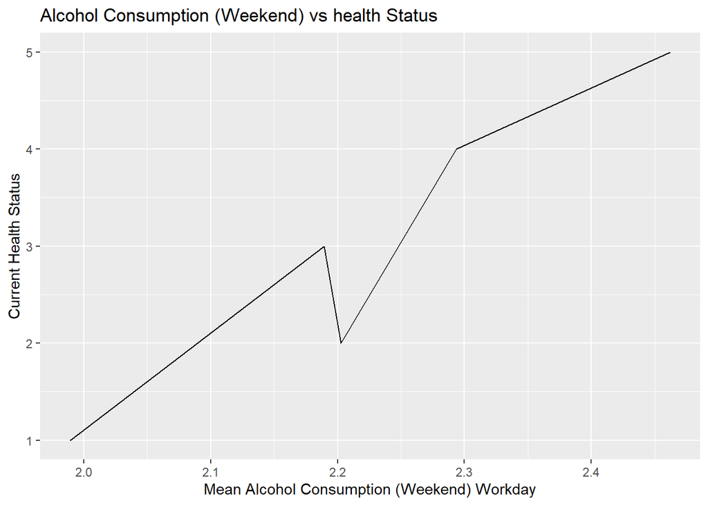

```r
ggplot(health_alc, aes(x=mean_walc, y=health)) +
  labs(title = "Alcohol Consumption (Weekend) vs health Status",
       x ='Mean Alcohol Consumption (Weekend) Workday', y ='Current Health Status')+
  geom_line()
```

Insights : The graphs show a positive relationship between drinking and health status. Being healthy drives higher consumption of alcohol, or alcohol leads healthy body? Generally, the latter would be more possible, but I cannot conclude here because the data doesn’t include a long term aspect. So the answer for the first question is **alcohol consumption and students’ health seem to relate each other, but this data doesn’t include enough facts to bring any meaningful conclusion**.

The second question, **does alcohol consumption relate to students’ school outcome, how?** would be answered by comparing students’ grade to their drinking amount.

### - Alcohol consumption vs Grade

```r
AveGrade_Dalc <- students %>%
  group_by(Dalc)%>%
  summarise(mean_grade_g1=mean(G1),mean_grade_g2=mean(G2),mean_grade_g3=mean(G3))
AveGrade_Dalc
```

```
## # A tibble: 5 x 4
##    Dalc mean_grade_g1 mean_grade_g2 mean_grade_g3
##   <int>         <dbl>         <dbl>         <dbl>
## 1     1         11.5          11.6          11.9
## 2     2         11.1          11.0          11.1
## 3     3         10.8          11.0          11.3
## 4     4          9.89          9.44          8.94
## 5     5          9.65         10.3          10.4
```

```r
AveGrade_Walc <- students %>%
  group_by(Walc)%>%
  summarise(mean_grade_g1=mean(G1),mean_grade_g2=mean(G2),mean_grade_g3=mean(G3))
AveGrade_Walc
```

```
## # A tibble: 5 x 4
##    Walc mean_grade_g1 mean_grade_g2 mean_grade_g3
##   <int>         <dbl>         <dbl>         <dbl>
## 1     1          11.6          11.7          12.0
## 2     2          11.6          11.5          11.8
## 3     3          11.3          11.4          11.5
## 4     4          10.5          10.5          10.7
## 5     5          10.3          10.5          10.6
```

#### Workday

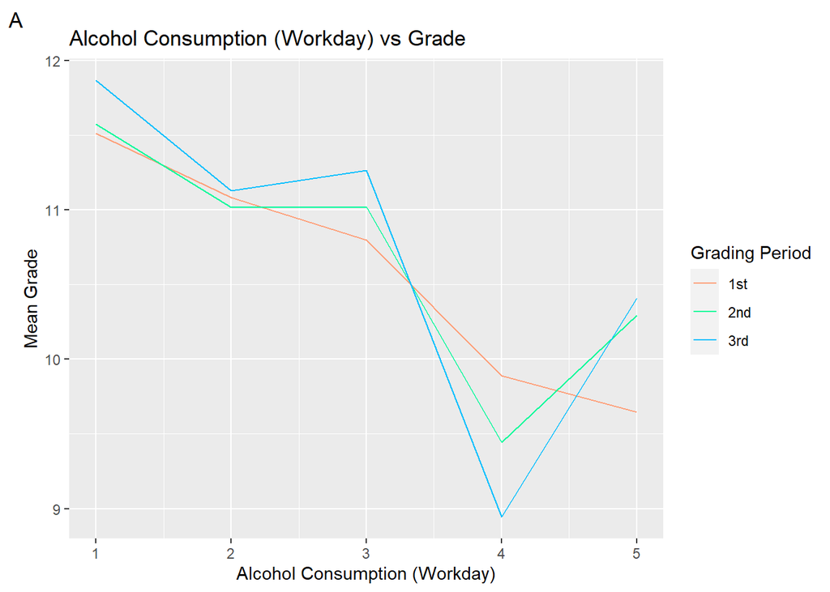

```r
ggplot(AveGrade_Dalc, aes(x=Dalc)) +
  geom_line(aes(y = mean_grade_g1, color = "1st")) +
  geom_line(aes(y = mean_grade_g2, color = "2nd")) +
  geom_line(aes(y = mean_grade_g3, color = "3rd")) +
  labs(title = "Alcohol Consumption (Workday) vs Grade",
       color = 'Grading Period',tag = "A") +
  xlab("Alcohol Consumption (Workday)") +
  ylab("Mean Grade")+
  scale_color_manual(values = c("lightsalmon", "mediumspringgreen","deepskyblue"))
```

#### Weekend

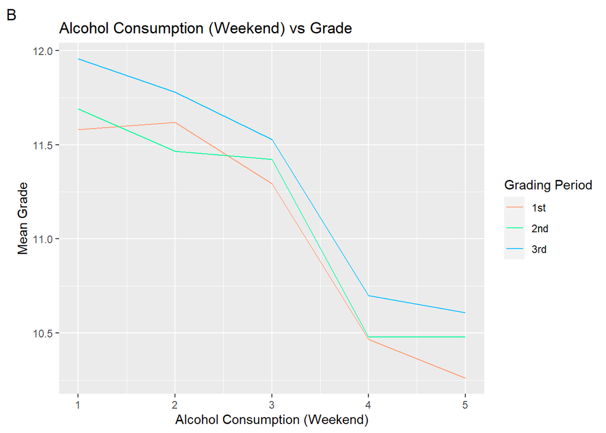

```r
ggplot(AveGrade_Walc, aes(x=Walc)) +
  geom_line(aes(y = mean_grade_g1, color = "1st")) +
  geom_line(aes(y = mean_grade_g2, color = "2nd")) +
  geom_line(aes(y = mean_grade_g3, color = "3rd")) +
  labs(title = "Alcohol Consumption (Weekend) vs Grade",
       color = 'Grading Period',tag = "B") +
  xlab("Alcohol Consumption (Weekend)") +
  ylab("Mean Grade")+
  scale_color_manual(values = c("lightsalmon", "mediumspringgreen","deepskyblue"))
```

Insights : It is clear that students’ grade and their alcohol intake strongly relate each other.

The answer for the second question, **does alcohol consumption relate to students’ school outcome, how?** can be explain by; **alcohol affects school grade negatively as the graphs show. The more the alcohol intake, the worse the school grade**. Now move on to figure out “how” alcohol affect students. The data has over 25 attributes, and those can be grouped in 5 categories (**a living location, family, goal-orientation, extra classes, and personal lifestyle**). Let’s see how each element connects to alcohol consumption.

- 1. Living location

### - Location

#### table

```r
# address: student's home address type (U:urban, R:rural)

Address_alc <- students %>%
  group_by(address)%>%
  summarise(mean_dalc=mean(Dalc),mean_walc=mean(Walc))
Address_alc
```

```
## # A tibble: 2 x 3
##   address mean_dalc mean_walc
##   <chr>       <dbl>     <dbl>
## 1 R            1.57      2.33
## 2 U            1.48      2.26
```

```r
Address_alc_m <- melt(Address_alc[,c('address','mean_dalc','mean_walc')], id.vars = 1)
```

#### plot

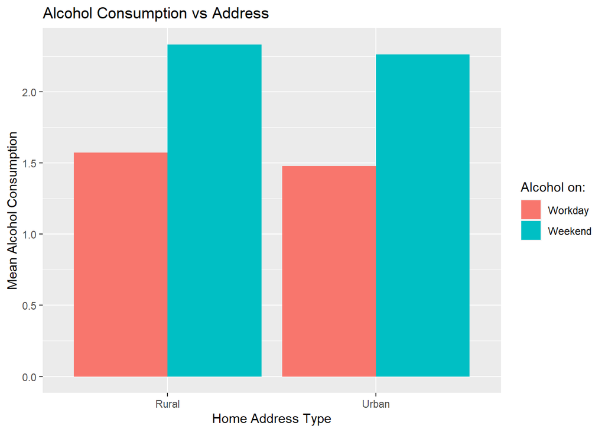

```r
ggplot(Address_alc_m,aes(x=address, y=value))+
  geom_bar(aes(fill=variable),stat = 'identity', position = "dodge") +
  labs(title = "Alcohol Consumption vs Address")+
  xlab("Home Address Type")+ ylab("Mean Alcohol Consumption") +
  scale_fill_discrete(name="Alcohol on:",
                      labels = c("Workday", "Weekend"))+
    scale_x_discrete(labels = c('R'='Rural','U'='Urban'))
```

### - Traveltime

#### table

```r
# traveltime : home to school travel time (1: < 15 min, 2: 15-30 min, 3: 30 min-1hour, 4: >1 hour)

tratime_alc <- students %>%
  group_by(traveltime)%>%
  summarise(mean_dalc=mean(Dalc),mean_walc=mean(Walc))
tratime_alc
```

```
## # A tibble: 4 x 3
##   traveltime mean_dalc mean_walc
##        <int>     <dbl>     <dbl>
## 1          1      1.47      2.26
## 2          2      1.50      2.24
## 3          3      1.65      2.48
## 4          4      2         2.81
```

```r
tratime_alc_m <- melt(tratime_alc[,c('traveltime','mean_dalc','mean_walc')], id.vars = 1)
```

#### plot

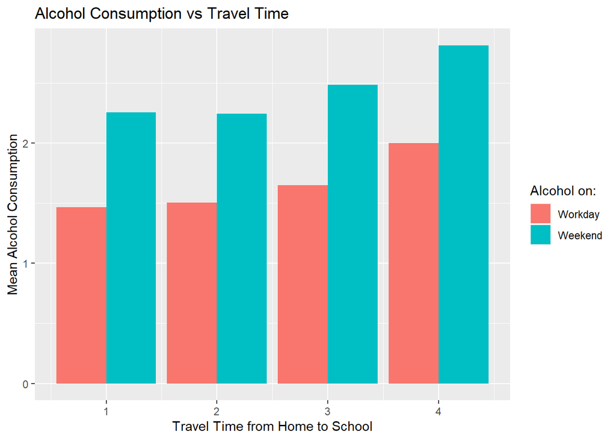

```r
ggplot(tratime_alc_m,aes(x=traveltime, y=value))+
  geom_bar(aes(fill=variable),stat = 'identity', position = "dodge") +
  labs(title = "Alcohol Consumption vs Travel Time")+
  xlab("Travel Time from Home to School")+ ylab("Mean Alcohol Consumption") +
  scale_fill_discrete(name="Alcohol on:", labels = c("Workday", "Weekend"))
```

Insights : From the aspect of students’ living location, alcohol intake doesn’t matter either in urban or rural, but it goes up as travel time increases.

- 2. Family

### - Parents’ Education

#### table(father)

```r
# Fedu: Father's education (0: none, 1: primary education(4th grade), 2: 5 -9th grade, 3: secondary education, 4:higher education)

fedu_alc <- students %>%
  group_by(Fedu)%>%
  summarise(mean_dalc=mean(Dalc),mean_walc=mean(Walc))
fedu_alc
```

```
## # A tibble: 5 x 3
##    Fedu mean_dalc mean_walc
##   <int>     <dbl>     <dbl>
## 1     0      1         1
## 2     1      1.56      2.32
## 3     2      1.50      2.23
## 4     3      1.41      2.38
## 5     4      1.55      2.30
```

```r
fedu_alc_m <- melt(fedu_alc[,c('Fedu','mean_dalc','mean_walc')], id.vars = 1)
```

#### plot(father)

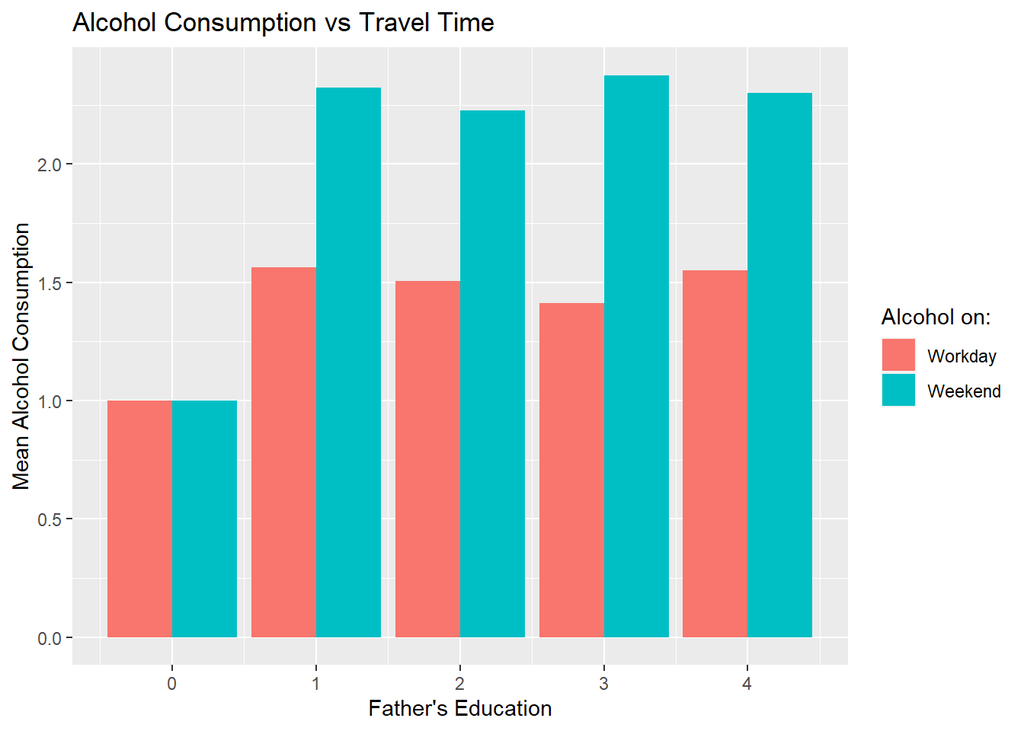

```r
ggplot(fedu_alc_m,aes(x=Fedu, y=value))+
  geom_bar(aes(fill=variable),stat = 'identity', position = "dodge") +
  labs(title = "Alcohol Consumption vs Travel Time")+
  xlab("Father's Education")+ ylab("Mean Alcohol Consumption") +
  scale_fill_discrete(name="Alcohol on:", labels = c("Workday", "Weekend"))
```

#### table(mother)

```r
# Medu : Mother's education

medu_alc <- students %>%
  group_by(Medu)%>%
  summarise(mean_dalc=mean(Dalc),mean_walc=mean(Walc))
medu_alc
```

```
## # A tibble: 5 x 3
##    Medu mean_dalc mean_walc
##   <int>     <dbl>     <dbl>
## 1     0      1.67      2.67
## 2     1      1.61      2.46
## 3     2      1.37      2.12
## 4     3      1.60      2.38
## 5     4      1.48      2.23
```

```r
medu_alc_m <- melt(medu_alc[,c('Medu','mean_dalc','mean_walc')], id.vars = 1)
```

#### plot(mother)

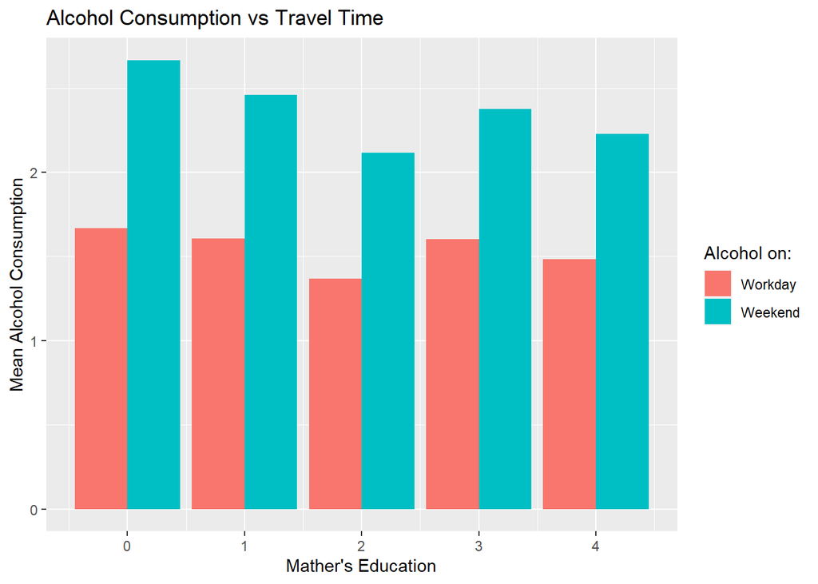

```r
ggplot(medu_alc_m,aes(x=Medu, y=value))+
  geom_bar(aes(fill=variable),stat = 'identity', position = "dodge") +
  labs(title = "Alcohol Consumption vs Travel Time")+
  xlab("Mather's Education")+ ylab("Mean Alcohol Consumption") +
  scale_fill_discrete(name="Alcohol on:", labels = c("Workday", "Weekend"))
```

### - Parents’ job

#### table(father)

```r
# Fjob : Father's job ('teacher', 'health' care related, civil 'services' (e.g. administrative or police), 'at_home' or 'other')

fjob_alc <- students %>%
  group_by(Fjob)%>%
  summarise(mean_dalc=mean(Dalc), mean_walc=mean(Walc))
fjob_alc
```

```
## # A tibble: 5 x 3
##   Fjob     mean_dalc mean_walc
##   <chr>        <dbl>     <dbl>
## 1 at_home       1.39      1.98
## 2 health        1.46      2.12
## 3 other         1.46      2.28
## 4 services      1.65      2.48
## 5 teacher       1.4       1.86
```

```r
fjob_alc_m <- melt(fjob_alc[,c('Fjob','mean_dalc','mean_walc')], id.vars = 1)
```

#### plot(father)

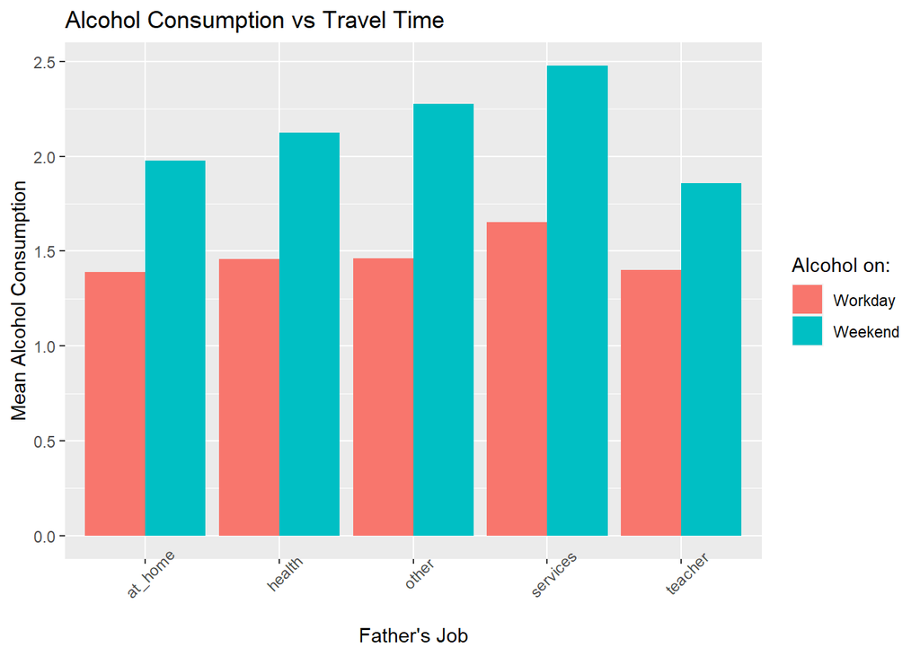

```r
ggplot(fjob_alc_m,aes(x=Fjob, y=value))+
  geom_bar(aes(fill=variable),stat = 'identity', position = "dodge") +
  labs(title = "Alcohol Consumption vs Travel Time")+
  xlab("Father's Job")+ ylab("Mean Alcohol Consumption") +
  scale_fill_discrete(name="Alcohol on:", labels = c("Workday", "Weekend"))+
  theme(axis.text.x = element_text(angle=45))
```

#### table(mother)

```r
# Mother's job (Mjob)

mjob_alc <- students %>%
  group_by(Mjob)%>%
  summarise(mean_dalc=mean(Dalc),mean_walc=mean(Walc))
mjob_alc
```

```
## # A tibble: 5 x 3
##   Mjob     mean_dalc mean_walc
##   <chr>        <dbl>     <dbl>
## 1 at_home       1.48      2.28
## 2 health        1.25      2.38
## 3 other         1.50      2.21
## 4 services      1.60      2.38
## 5 teacher       1.57      2.31
```

```r
mjob_alc_m <- melt(mjob_alc[,c('Mjob','mean_dalc','mean_walc')], id.vars = 1)
```

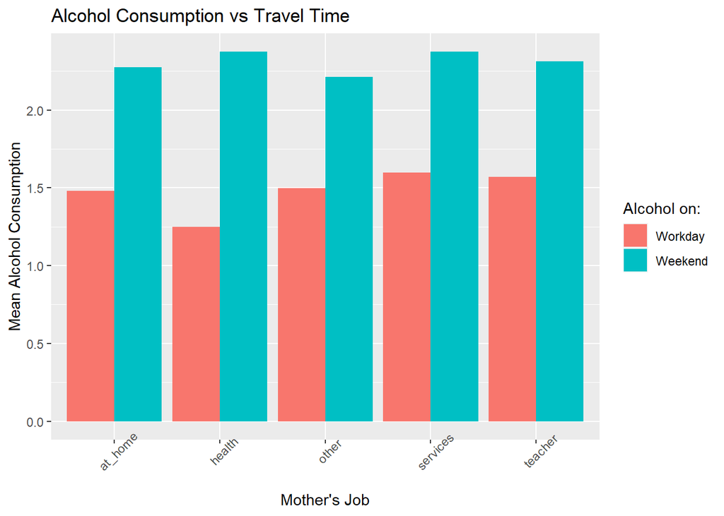

```r
ggplot(mjob_alc_m,aes(x=Mjob, y=value))+
  geom_bar(aes(fill=variable),stat = 'identity', position = "dodge") +
  labs(title = "Alcohol Consumption vs Travel Time")+
  xlab("Mother's Job")+ ylab("Mean Alcohol Consumption") +
  scale_fill_discrete(name="Alcohol on:", labels = c("Workday", "Weekend"))+
  theme(axis.text.x = element_text(angle=45))
```

### - Student’s guardian

#### table

```r
# guardian : Student's guardian  ('mother', 'father' or 'other')

guard_alc <- students %>%
  group_by(guardian)%>%
  summarise(mean_dalc=mean(Dalc),mean_walc=mean(Walc))
guard_alc
```

```
## # A tibble: 3 x 3
##   guardian mean_dalc mean_walc
##   <chr>        <dbl>     <dbl>
## 1 father        1.57      2.32
## 2 mother        1.45      2.29
## 3 other         1.77      2.16
```

```r
guard_alc_m <- melt(guard_alc[,c('guardian','mean_dalc','mean_walc')], id.vars = 1)
```

#### plot

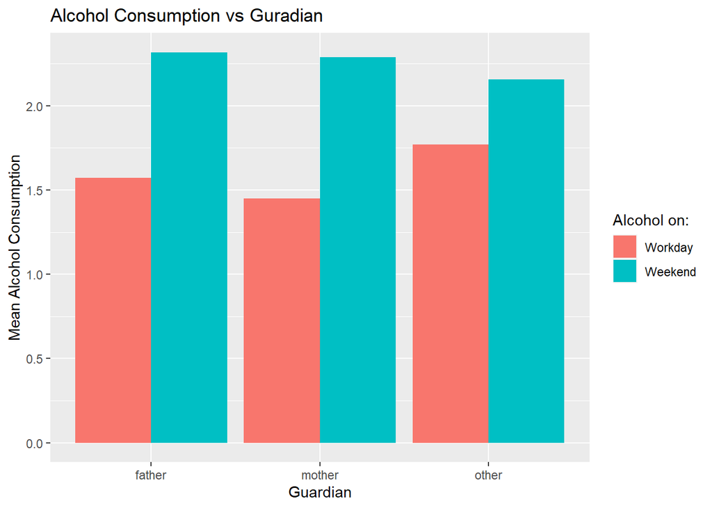

```r
ggplot(guard_alc_m,aes(x=guardian, y=value))+
  geom_bar(aes(fill=variable),stat = 'identity', position = "dodge") +
  labs(title = "Alcohol Consumption vs Guradian")+
  xlab("Guardian")+ ylab("Mean Alcohol Consumption") +
  scale_fill_discrete(name="Alcohol on:", labels = c("Workday", "Weekend"))
```

### - Cohabitation with parents

#### table

```r
# Pstatus : parent's cohabitation with parent (T: living together, A: apart)

psta_alc <- students %>%
  group_by(Pstatus)%>%
  summarise(mean_dalc=mean(Dalc),mean_walc=mean(Walc))
psta_alc
```

```
## # A tibble: 2 x 3
##   Pstatus mean_dalc mean_walc
##   <chr>       <dbl>     <dbl>
## 1 A            1.42      2.10
## 2 T            1.52      2.31
```

```r
psta_alc_m <- melt(psta_alc[,c('Pstatus','mean_dalc','mean_walc')], id.vars = 1)
```

#### plot

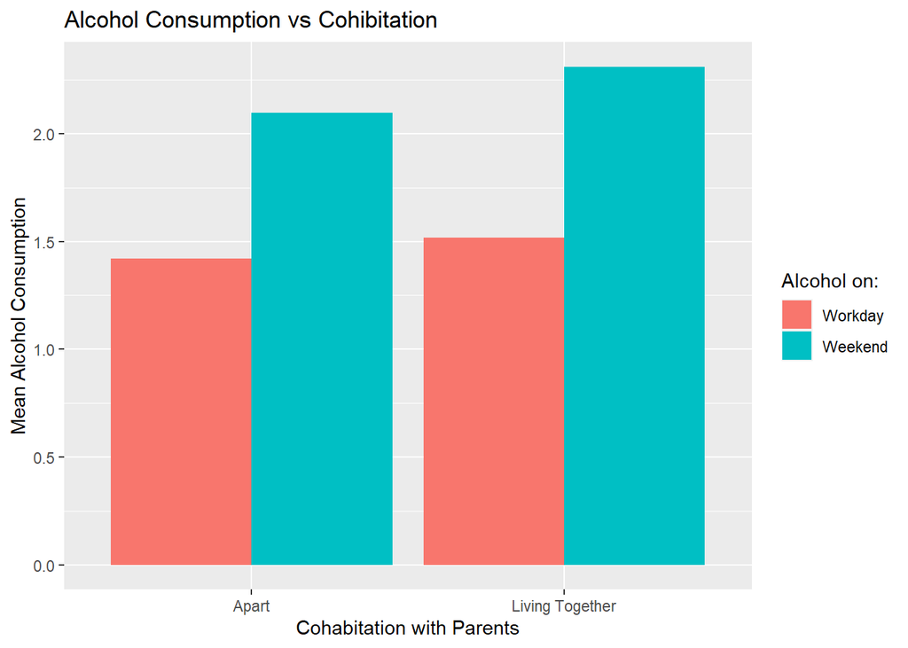

```r
ggplot(psta_alc_m,aes(x=Pstatus, y=value))+
  geom_bar(aes(fill=variable),stat = 'identity', position = "dodge") +
  labs(title = "Alcohol Consumption vs Cohibitation")+
  xlab("Cohabitation with Parents")+ ylab("Mean Alcohol Consumption") +
  scale_fill_discrete(name="Alcohol on:", labels = c("Workday", "Weekend"))+
  scale_x_discrete(labels = c('T'= 'Living Together', 'A' = 'Apart'))
```

### - Family size

#### table

```r
# Size of family binary: 'LE3' - less or equal to 3 or 'GT3' - greater than 3) (famsize)

fansize_alc <- students %>%
  group_by(famsize)%>%
  summarise(mean_dalc=mean(Dalc),mean_walc=mean(Walc))
fansize_alc
```

```
## # A tibble: 2 x 3
##   famsize mean_dalc mean_walc
##   <chr>       <dbl>     <dbl>
## 1 GT3          1.46      2.21
## 2 LE3          1.60      2.46
```

```r
fansize_alc_m <- melt(fansize_alc[,c('famsize','mean_dalc','mean_walc')], id.vars = 1)
```

#### plot

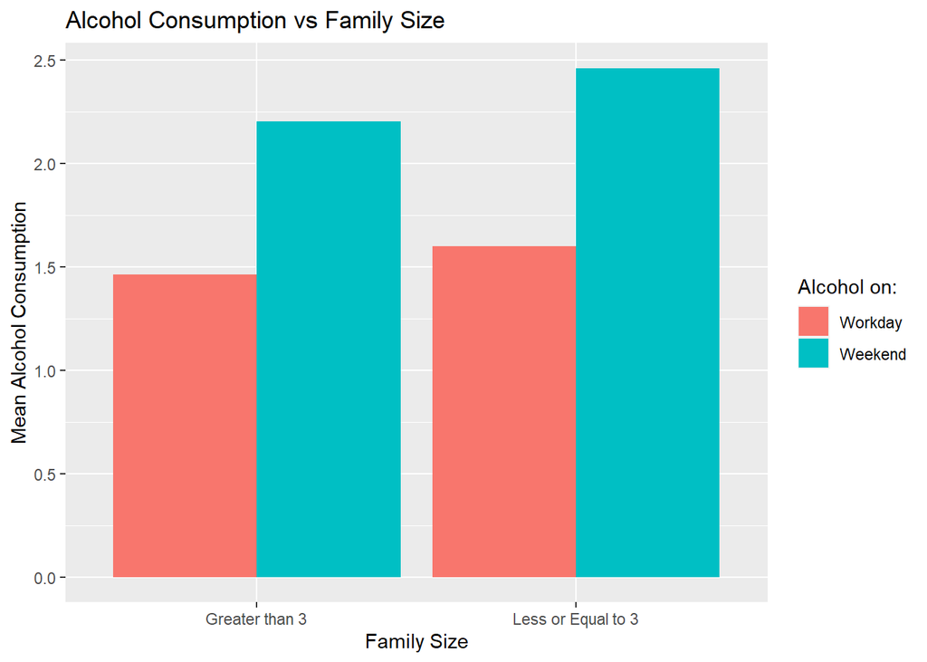

```r
ggplot(fansize_alc_m,aes(x=famsize, y=value))+
  geom_bar(aes(fill=variable),stat = 'identity', position = "dodge") +
  labs(title = "Alcohol Consumption vs Family Size")+
  xlab("Family Size")+ ylab("Mean Alcohol Consumption") +
  scale_fill_discrete(name="Alcohol on:", labels = c("Workday", "Weekend"))+
  scale_x_discrete(labels = c('LE3'= 'Less or Equal to 3', 'GT3' ='Greater than 3'))
```

### - Relationship with family

#### table

```r
# Famrel : Relationship with family (From 1:very bad to 5:excellent)

famrel_alc <- students %>%
  group_by(famrel)%>%
  summarise(mean_dalc=mean(Dalc),mean_walc=mean(Walc))
famrel_alc
```

```
## # A tibble: 5 x 3
##   famrel mean_dalc mean_walc
##    <int>     <dbl>     <dbl>
## 1      1      1.95      2.43
## 2      2      1.72      2.66
## 3      3      1.48      2.46
## 4      4      1.47      2.26
## 5      5      1.49      2.16
```

```r
famrel_alc_m <- melt(famrel_alc[,c('famrel','mean_dalc','mean_walc')], id.vars = 1)
```

#### plot

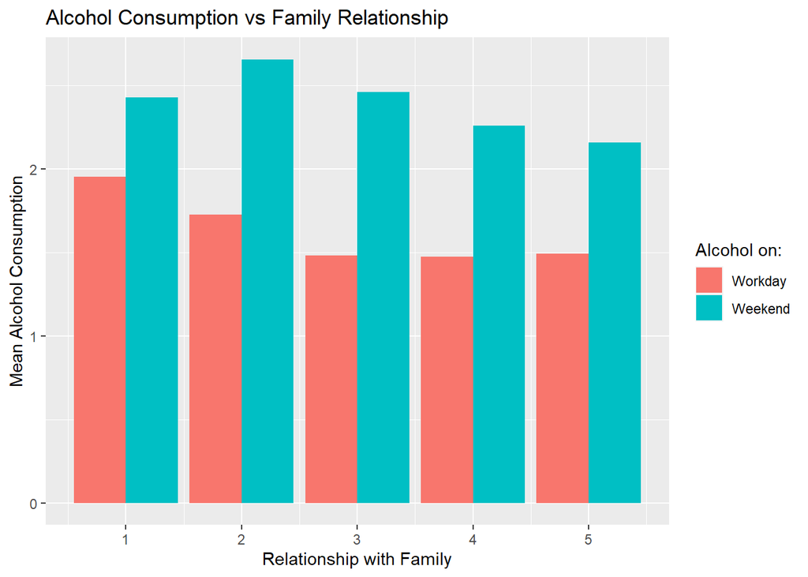

```r
ggplot(famrel_alc_m,aes(x=famrel, y=value))+
  geom_bar(aes(fill=variable),stat = 'identity', position = "dodge") +
  labs(title = "Alcohol Consumption vs Family Relationship")+
  xlab("Relationship with Family")+ ylab("Mean Alcohol Consumption") +
  scale_fill_discrete(name="Alcohol on:", labels = c("Workday", "Weekend"))
```

### - Educational support from family

#### table

```r
# famsup : Educational support from family (yes or no)

famsup_alc <- students %>%
  group_by(famsup)%>%
  summarise(mean_dalc=mean(Dalc),mean_walc=mean(Walc))
famsup_alc
```

```
## # A tibble: 2 x 3
##   famsup mean_dalc mean_walc
##   <chr>      <dbl>     <dbl>
## 1 no          1.53      2.39
## 2 yes         1.49      2.22
```

```r
famsup_alc_m <- melt(famsup_alc[,c('famsup','mean_dalc','mean_walc')], id.vars = 1)
```

#### plot

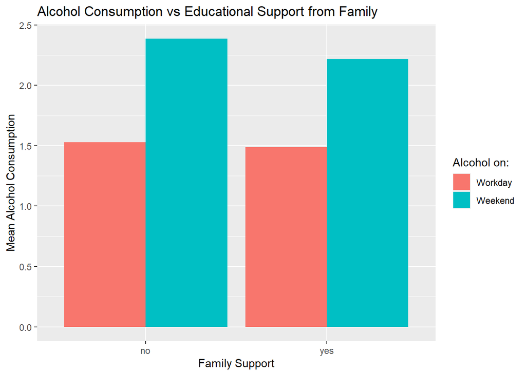

```r
ggplot(famsup_alc_m,aes(x=famsup, y=value))+
  geom_bar(aes(fill=variable),stat = 'identity', position = "dodge") +
  labs(title = "Alcohol Consumption vs Educational Support from Family")+
  xlab("Family Support")+ ylab("Mean Alcohol Consumption") +
  scale_fill_discrete(name="Alcohol on:", labels = c("Workday", "Weekend"))
```

Insights : Students who live with parents, and have family members equal or less than 3 tend to intake more alcohol than people who are in the opposite situation. On the other hand, students having a strong family relationship and getting family support tend to keep their alcohol intake low.

- 3. Goal-orientation

### - Number of school absences

#### table

```r
# number of school absences (from 0 to 93) (absences)

absence_alc_all <- students %>%
  select(absences,Dalc, Walc)
head(absence_alc_all)
```

```
##   absences Dalc Walc
## 1        4    1    1
## 2        2    1    1
## 3        2    2    4
## 4        8    1    1
## 5        2    1    1
## 6        2    2    3
```

#### plot

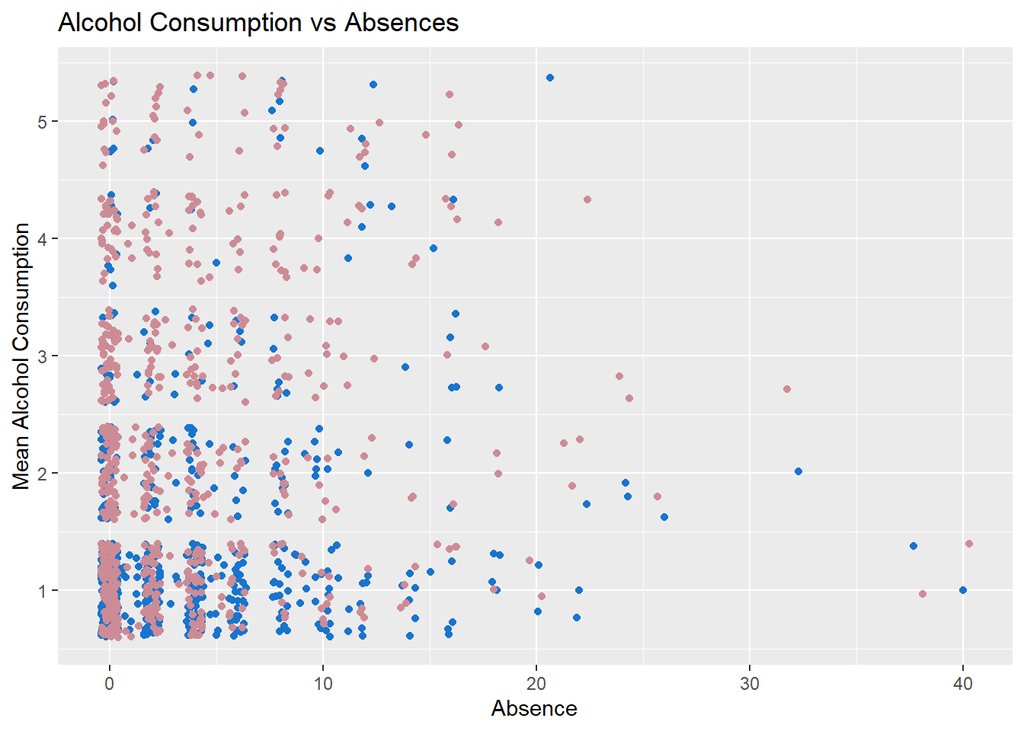

```r
ggplot(absence_alc_all,aes(x=absences))+
  geom_jitter(aes(y = Dalc) , color = 'dodgerblue3') +
  geom_jitter(aes(y = Walc) , color = 'lightpink3') +
  labs(title = "Alcohol Consumption vs Absences")+
  xlab("Absence")+ ylab("Mean Alcohol Consumption") +
  scale_fill_discrete(name="Alcohol on:",
                      labels=c("Workday", "Weekend"))
```

### - Number of past class failures

#### table

```r
# failures : number of past class failures (n if 1<=n<3, else 4)
fail_alc_all <- students %>%
  select(failures,Dalc, Walc)
head(fail_alc_all)
```

```
##   failures Dalc Walc
## 1        0    1    1
## 2        1    1    1
## 3        0    2    4
## 4        0    1    1
## 5        0    1    1
## 6        0    2    3
```

#### plot

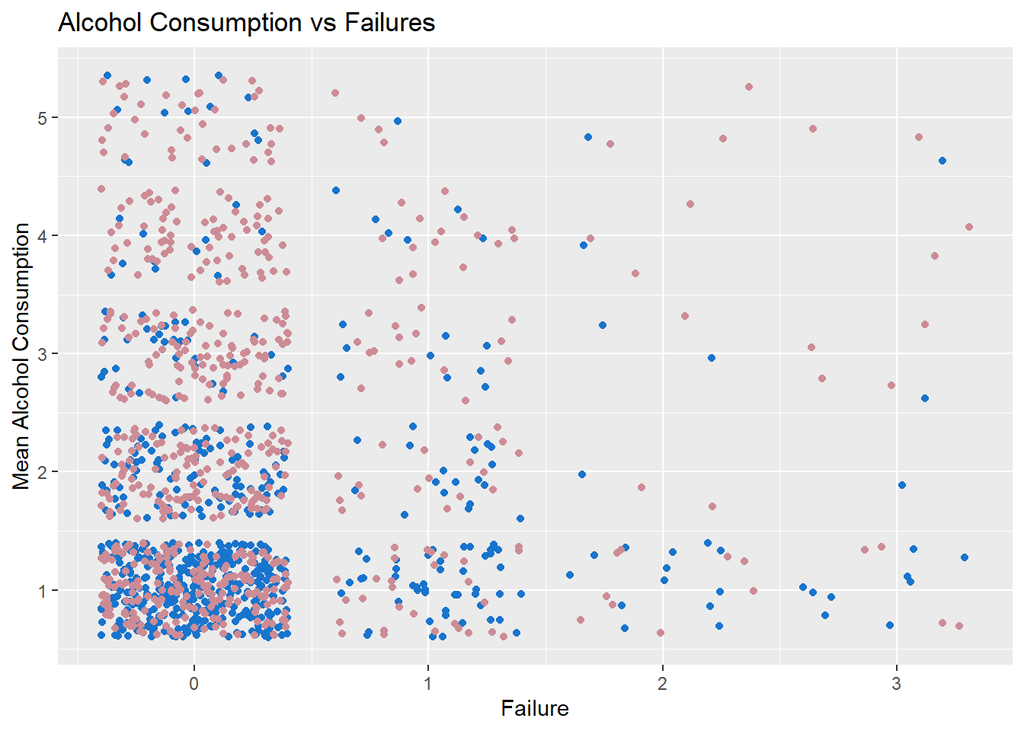

```r
ggplot(fail_alc_all,aes(x=failures))+
  geom_jitter(aes(y = Dalc) , color = 'dodgerblue3') +
  geom_jitter(aes(y = Walc) , color = 'lightpink3') +
  labs(title = "Alcohol Consumption vs Failures")+
  xlab("Failure")+ ylab("Mean Alcohol Consumption") +
  scale_fill_discrete(name="Alcohol on:",
                      labels=c("Workday", "Weekend"))
```

### - Aspiration for higher education

#### table

```r
# higher : Aspiration for higher education (yes or no)
high_alc <- students %>%
  group_by(higher)%>%
  summarise(mean_dalc=mean(Dalc),mean_walc=mean(Walc))
high_alc
```

```
## # A tibble: 2 x 3
##   higher mean_dalc mean_walc
##   <chr>      <dbl>     <dbl>
## 1 no          1.83      2.62
## 2 yes         1.47      2.24
```

```r
high_alc_m <- melt(high_alc[,c('higher','mean_dalc','mean_walc')], id.vars = 1)
```

#### plot

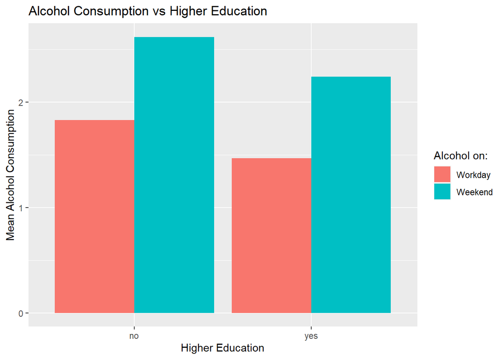

```r
ggplot(high_alc_m,aes(x=higher, y=value))+
  geom_bar(aes(fill=variable),stat = 'identity', position = "dodge") +
  labs(title = "Alcohol Consumption vs Higher Education")+
  xlab("Higher Education")+ ylab("Mean Alcohol Consumption") +
  scale_fill_discrete(name="Alcohol on:", labels = c("Workday", "Weekend"))
```

### - Weekly study time

#### table

```r
# studytime : weekly study time (1: <2 hours, 2: 2-5 hours, 3: 5-10 hours, 4: >10 hours)

stu_time_alc <- students %>%
  group_by(studytime)%>%
  summarise(mean_dalc=mean(Dalc),mean_walc=mean(Walc))
stu_time_alc
```

```
## # A tibble: 4 x 3
##   studytime mean_dalc mean_walc
##       <int>     <dbl>     <dbl>
## 1         1      1.74      2.69
## 2         2      1.41      2.19
## 3         3      1.28      1.81
## 4         4      1.54      1.97
```

```r
stu_time_alc_m <- melt(stu_time_alc[,c('studytime','mean_dalc','mean_walc')], id.vars = 1)
```

#### plot

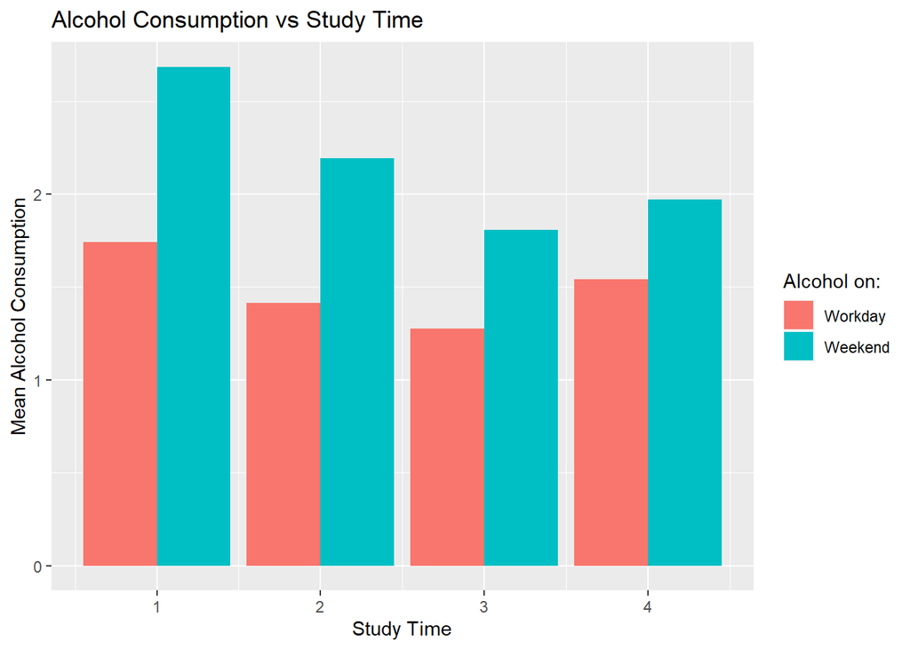

```r
ggplot(stu_time_alc_m,aes(x=studytime, y=value))+
  geom_bar(aes(fill=variable),stat = 'identity', position = "dodge") +
  labs(title = "Alcohol Consumption vs Study Time")+
  xlab("Study Time")+ ylab("Mean Alcohol Consumption") +
  scale_fill_discrete(name="Alcohol on:", labels = c("Workday", "Weekend"))
```

Insights : Drinking doesn’t seem to relate to the number of school absences and class failures. However, students who want to take higher education and study harder (especially studying for 5 - 10 hours/week) have the least amount of alcohol of all. Note that studying over 10 hours increases the level of drinking.

- 4. Extra classes

### - Extra curricular activities

#### table

```r
# activities : extra curricular activities (yes or no)

active_curr_alc <- students %>%
  group_by(activities)%>%
  summarise(mean_dalc=mean(Dalc),mean_walc=mean(Walc))
active_curr_alc
```

```
## # A tibble: 2 x 3
##   activities mean_dalc mean_walc
##   <chr>          <dbl>     <dbl>
## 1 no              1.49      2.25
## 2 yes             1.53      2.32
```

```r
active_curr_alc_m <- melt(active_curr_alc[,c('activities','mean_dalc','mean_walc')], id.vars = 1)
```

#### plot

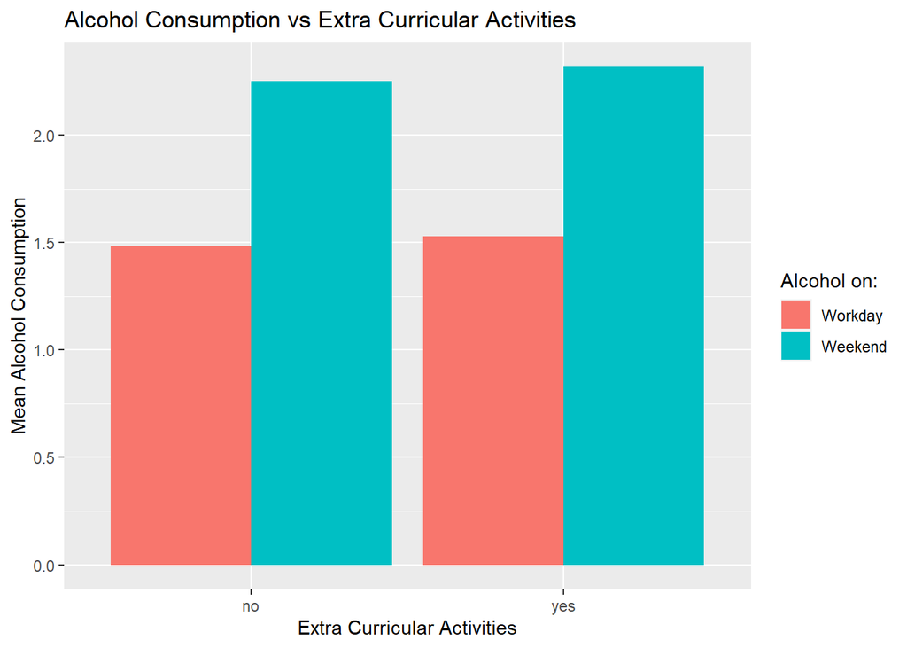

```r
ggplot(active_curr_alc_m,aes(x=activities, y=value))+
  geom_bar(aes(fill=variable),stat = 'identity', position = "dodge") +
  labs(title = "Alcohol Consumption vs Extra Curricular Activities")+
  xlab("Extra Curricular Activities")+ ylab("Mean Alcohol Consumption") +
  scale_fill_discrete(name="Alcohol on:", labels = c("Workday", "Weekend"))
```

### - Attended nursery school

#### table

```r
# nursery : attended nursery school (yes or no)
nursery_alc <- students %>%
  group_by(nursery)%>%
  summarise(mean_dalc=mean(Dalc),mean_walc=mean(Walc))
nursery_alc
```

```
## # A tibble: 2 x 3
##   nursery mean_dalc mean_walc
##   <chr>       <dbl>     <dbl>
## 1 no           1.64      2.45
## 2 yes          1.47      2.24
```

```r
nursery_alc_m <- melt(nursery_alc[,c('nursery','mean_dalc','mean_walc')], id.vars = 1)
```

#### plot

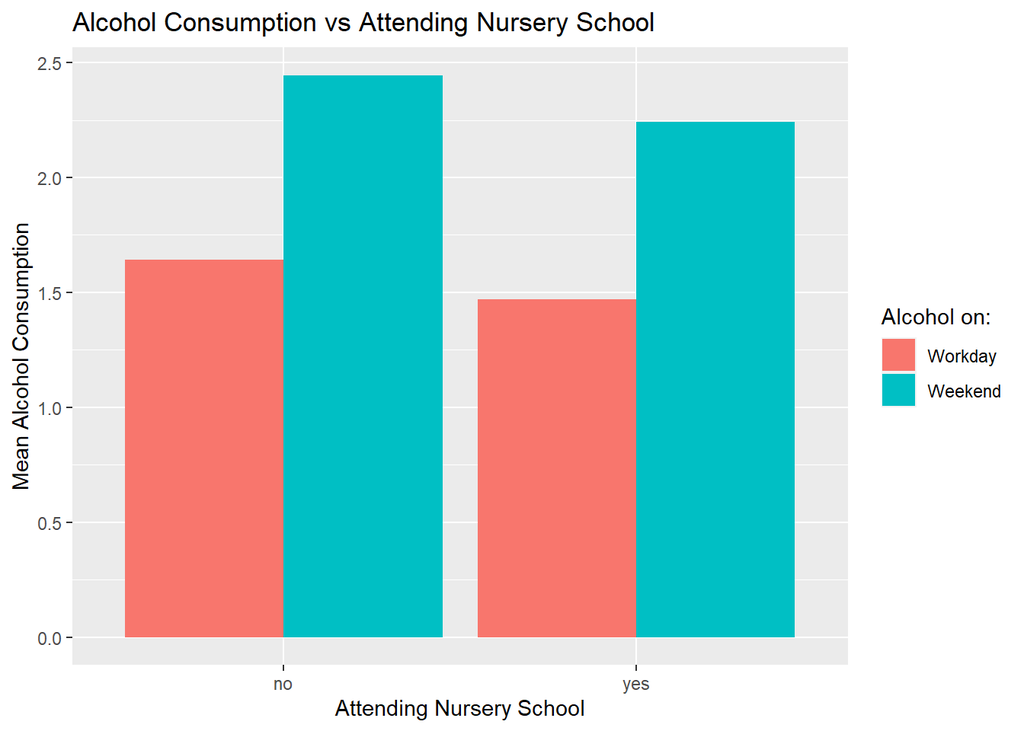

```r
ggplot(nursery_alc_m,aes(x=nursery, y=value))+
  geom_bar(aes(fill=variable),stat = 'identity', position = "dodge") +
  labs(title = "Alcohol Consumption vs Attending Nursery School")+
  xlab("Attending Nursery School")+ ylab("Mean Alcohol Consumption") +
  scale_fill_discrete(name="Alcohol on:", labels = c("Workday", "Weekend"))
```

### - Extra paid classes within the course subject

#### table

```r
# Paid : extra paid classes within the course subject (Math or Portuguese) (yes or no)
paid_alc <- students %>%
  group_by(paid)%>%
  summarise(mean_dalc=mean(Dalc),mean_walc=mean(Walc))
paid_alc
```

```
## # A tibble: 2 x 3
##   paid  mean_dalc mean_walc
##   <chr>     <dbl>     <dbl>
## 1 no         1.49      2.27
## 2 yes        1.76      2.58
```

```r
paid_alc_m <- melt(paid_alc[,c('paid','mean_dalc','mean_walc')], id.vars = 1)
```

#### plot

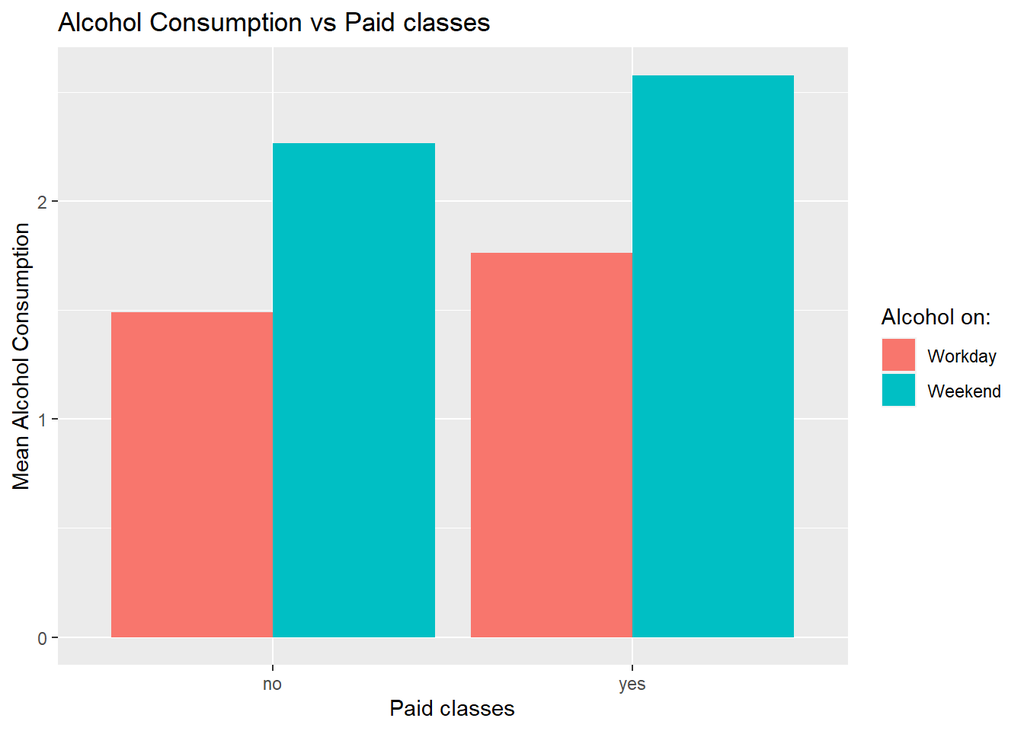

```r
ggplot(paid_alc_m,aes(x=paid, y=value))+
  geom_bar(aes(fill=variable),stat = 'identity', position = "dodge") +
  labs(title = "Alcohol Consumption vs Paid classes")+
  xlab("Paid classes")+ ylab("Mean Alcohol Consumption") +
  scale_fill_discrete(name="Alcohol on:", labels = c("Workday", "Weekend"))
```

### - Extra educational support from school

#### table

```r
# scholsup : extra educational support (yes or no)
schoolsup_alc <- students %>%
  group_by(schoolsup)%>%
  summarise(mean_dalc=mean(Dalc),mean_walc=mean(Walc))
schoolsup_alc
```

```
## # A tibble: 2 x 3
##   schoolsup mean_dalc mean_walc
##   <chr>         <dbl>     <dbl>
## 1 no             1.52      2.32
## 2 yes            1.42      1.97
```

```r
schoolsup_alc_m <- melt(schoolsup_alc[,c('schoolsup','mean_dalc','mean_walc')], id.vars = 1)
```

#### plot

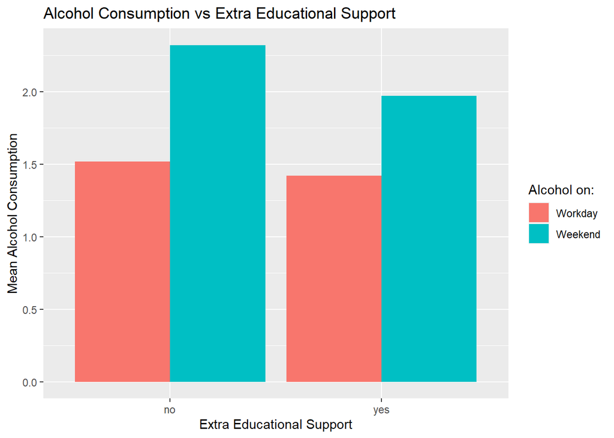

```r
ggplot(schoolsup_alc_m,aes(x=schoolsup, y=value))+
  geom_bar(aes(fill=variable),stat = 'identity', position = "dodge") +
  labs(title = "Alcohol Consumption vs Extra Educational Support")+
  xlab("Extra Educational Support")+ ylab("Mean Alcohol Consumption") +
  scale_fill_discrete(name="Alcohol on:", labels = c("Workday", "Weekend"))
```

Insights : It seems extra classes and curricula can relate to higher alcohol consumption. Like students who study over 10 hours, drinking might relate to students’ stress level, while students who get extra educational support from school have lower drinking level than students without the support.

- 5. Personal Lifestyle

### - Going out with friends

#### table

```r
# goout : going out with friends (1:very low - 5:very high)
goout_alc <- students %>%
  group_by(goout)%>%
  summarise(mean_dalc=mean(Dalc),mean_walc=mean(Walc))
goout_alc
```

```
## # A tibble: 5 x 3
##   goout mean_dalc mean_walc
##   <int>     <dbl>     <dbl>
## 1     1      1.17      1.58
## 2     2      1.30      1.77
## 3     3      1.42      2.10
## 4     4      1.63      2.62
## 5     5      1.95      3.21
```

```r
goout_alc_m <- melt(goout_alc[,c('goout','mean_dalc','mean_walc')],id.vars = 1)
```

#### barplot

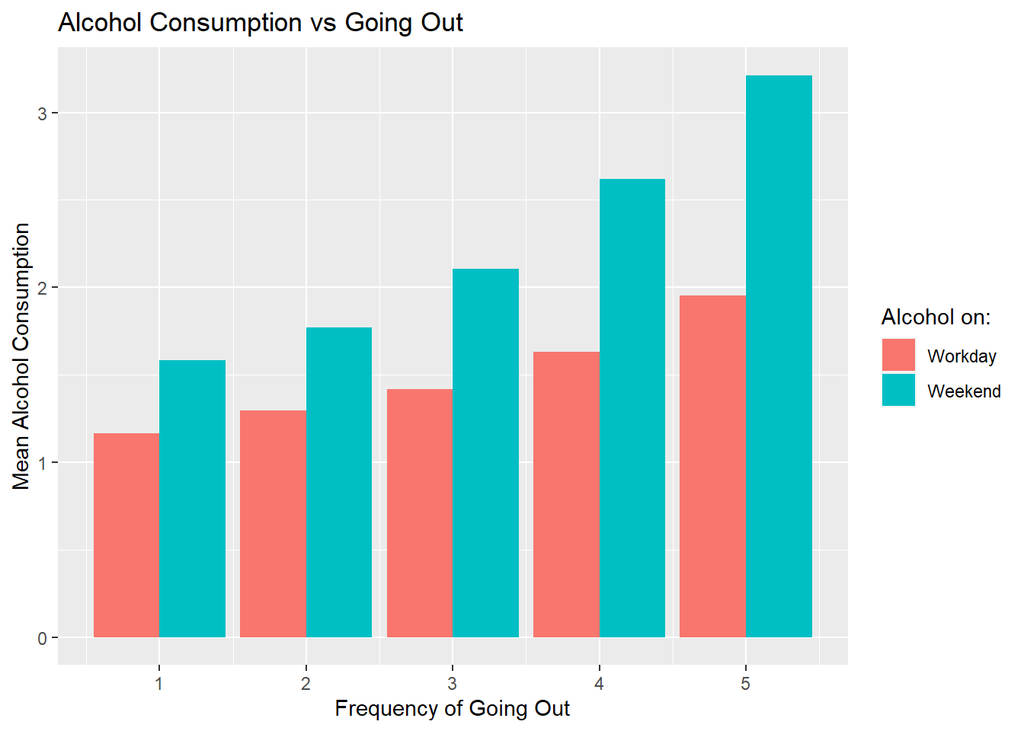

```r
ggplot(goout_alc_m,aes(x=goout, y=value))+
  geom_bar(aes(fill=variable),stat = 'identity', position = "dodge") +
  labs(title = "Alcohol Consumption vs Going Out")+
  xlab("Frequency of Going Out")+ ylab("Mean Alcohol Consumption") +
  scale_fill_discrete(name="Alcohol on:",
                        labels=c("Workday", "Weekend"))
```

### - Romantic Relationship

#### table

```r
# romantic : with a romantic relationship (yes or no)
romantic_alc <- students %>%
  group_by(romantic)%>%
  summarise(mean_dalc=mean(Dalc),mean_walc=mean(Walc))
romantic_alc
```

```
## # A tibble: 2 x 3
##   romantic mean_dalc mean_walc
##   <chr>        <dbl>     <dbl>
## 1 no            1.48      2.32
## 2 yes           1.55      2.23
```

```r
romantic_alc_m <- melt(romantic_alc[,c('romantic','mean_dalc','mean_walc')],id.vars = 1)
```

#### barplot

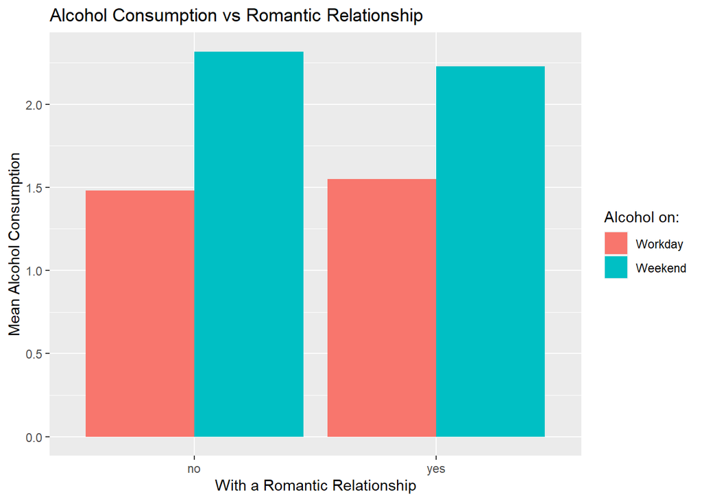

```r
ggplot(romantic_alc_m,aes(x=romantic, y=value))+
  geom_bar(aes(fill=variable),stat = 'identity', position = "dodge") +
  labs(title = "Alcohol Consumption vs Romantic Relationship")+
  xlab("With a Romantic Relationship")+ ylab("Mean Alcohol Consumption") +
  scale_fill_discrete(name="Alcohol on:",
                        labels=c("Workday", "Weekend"))
```

### - Free time after school

#### table

```r
# freetime : free time after school (1:very low - 5: very high)
free_alc <- students %>%
  group_by(freetime)%>%
  summarise(mean_dalc=mean(Dalc),mean_walc=mean(Walc))
free_alc
```

```
## # A tibble: 5 x 3
##   freetime mean_dalc mean_walc
##      <int>     <dbl>     <dbl>
## 1        1      1.55      2.04
## 2        2      1.38      2.16
## 3        3      1.38      2.15
## 4        4      1.62      2.46
## 5        5      1.83      2.64
```

```r
free_alc_m <- melt(free_alc[,c('freetime','mean_dalc','mean_walc')],id.vars = 1)
```

#### barplot

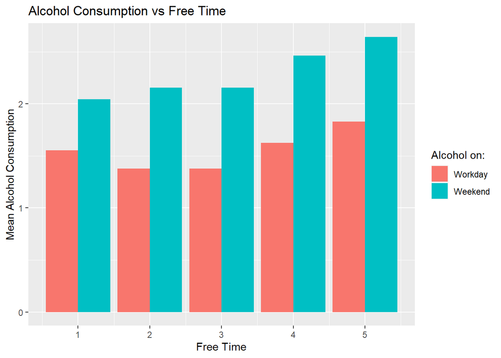

```r
ggplot(free_alc_m,aes(x=freetime, y=value))+
  geom_bar(aes(fill=variable),stat = 'identity', position = "dodge") +
  labs(title = "Alcohol Consumption vs Free Time")+
  xlab("Free Time")+ ylab("Mean Alcohol Consumption") +
  scale_fill_discrete(name="Alcohol on:",
                        labels=c("Workday", "Weekend"))
```

Additionally, see how study time relate to free time and school grade.

### - Free time vs Study Time

#### table

```r
# freetime : free time after school (1:very low - 5: very high)
# studytime : weekly study time (1: <2 hours, 2: 2-5 hours, 3: 5-10 hours, 4: >10 hours)

free_study_mean <- students %>%
    group_by(studytime) %>%
    summarise(mean_freetime=mean(freetime))
free_study_mean
```

```
## # A tibble: 4 x 2
##   studytime mean_freetime
##       <int>         <dbl>
## 1         1          3.27
## 2         2          3.18
## 3         3          3.06
## 4         4          2.97
```

#### plot

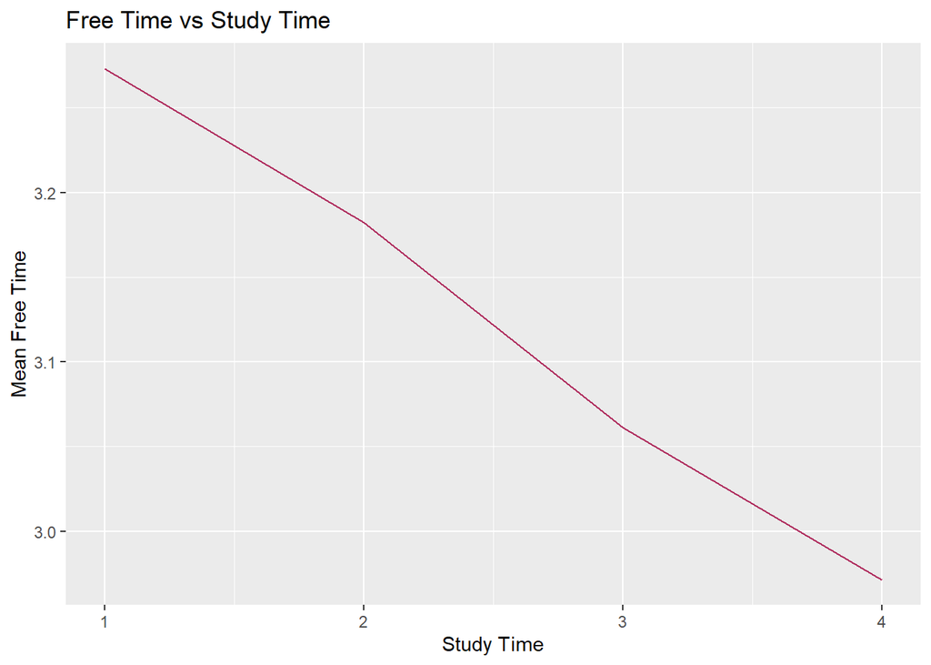

```r
ggplot(free_study_mean, aes(x=studytime)) +
  geom_line(aes(y = mean_freetime), color = 'maroon')+
  labs(title = "Free Time vs Study Time")+
  xlab("Study Time")+ ylab("Mean Free Time")
```

### - Study Time vs School Grade

#### table

```r
# studytime : weekly study time (1: <2 hours, 2: 2-5 hours, 3: 5-10 hours, 4: >10 hours)

mean_grade_study <- students %>%
  group_by(studytime)%>%
  summarise(mean_grade1=mean(G1),mean_grade2=mean(G2),mean_grade3=mean(G3))
mean_grade_study
```

```
## # A tibble: 4 x 4
##   studytime mean_grade1 mean_grade2 mean_grade3
##       <int>       <dbl>       <dbl>       <dbl>
## 1         1        10.4        10.5        10.6
## 2         2        11.4        11.4        11.7
## 3         3        12.4        12.6        13.0
## 4         4        12.5        12.4        12.2
```

#### plot

[figure not shown]

```r
ggplot(mean_grade_study, aes(x = studytime))+
  geom_line(aes(y = mean_grade1, colour = 'pink')) +
  geom_line(aes(y = mean_grade2, colour = 'green')) +
  geom_line(aes(y = mean_grade3, colour = 'blue')) +
  labs(title = "School Grade vs Study Time",
       x ='Study Time (hours)', y ='Mean School Grade') +
  scale_colour_discrete(name ='School Period', labels =  c('1st','2nd','3rd'))+
  scale_x_discrete(limit = c('<2', '2-5','5-10','>10'))
```

Insights : In personal lifestyle aspects, going out with friends most likely triggers drinking, and having more free time also has a positive relationship with alcohol. Since free time and study time are inversely proportional each other, time management affects students’ alcohol consumption and their academic performance.

## Solution

- Having higher goals can lead higher performance
- Manage your study hours and the number of extra classes with one’s stress level (This can be challenging, because sometimes students don’t have a choice, or they want to despite of their capacity)
- Take advantage of school counselors
- Manage one’s free time (the frequency of going out with friends) in a rational way.

## Conclusion

Alcohol negatively affects students’ school performance. Each factor (a living location, family, goal-orientation, extra classes, and personal lifestyle) connects to drinking somehow. Some factors can be handled by students themselves, but others should be supported by their family members. It is important for students and their family members to understand what factors more likely relate to drinking, and by controlling alcohol can improve their academic performance.

## Next steps

Each student has a different personality, so they have to find their own balance. By keep trying, eventually everyone will know their best balance.